# Analyse Correspondance Multiple

Serigne Fallou Mbacke NGOM

2023-03-10

ACM permet de visualiser et d’analyser plusieurs variables qualitatives.

```r
library('FactoMineR')
library('factoextra')
data("poison")
head(poison)
```

```
##   Age Time   Sick Sex   Nausea Vomiting Abdominals   Fever   Diarrhae   Potato
## 1   9   22 Sick_y   F Nausea_y  Vomit_n     Abdo_y Fever_y Diarrhea_y Potato_y
## 2   5    0 Sick_n   F Nausea_n  Vomit_n     Abdo_n Fever_n Diarrhea_n Potato_y
## 3   6   16 Sick_y   F Nausea_n  Vomit_y     Abdo_y Fever_y Diarrhea_y Potato_y
## 4   9    0 Sick_n   F Nausea_n  Vomit_n     Abdo_n Fever_n Diarrhea_n Potato_y
## 5   7   14 Sick_y   M Nausea_n  Vomit_y     Abdo_y Fever_y Diarrhea_y Potato_y
## 6  72    9 Sick_y   M Nausea_n  Vomit_n     Abdo_y Fever_y Diarrhea_y Potato_y
##     Fish   Mayo Courgette   Cheese   Icecream
## 1 Fish_y Mayo_y   Courg_y Cheese_y Icecream_y
## 2 Fish_y Mayo_y   Courg_y Cheese_n Icecream_y
## 3 Fish_y Mayo_y   Courg_y Cheese_y Icecream_y
## 4 Fish_y Mayo_n   Courg_y Cheese_y Icecream_y
## 5 Fish_y Mayo_y   Courg_y Cheese_y Icecream_y
## 6 Fish_n Mayo_y   Courg_y Cheese_y Icecream_y
```

Poison est une base de donnees contenant des aliments provenants d’une ecole ou on a une TIAC et on essaye de voir l’aliment responsable (_y=yes ; _n=no).

```r
poison_symptomes = poison[, 5:9]
summary(poison_symptomes)
```

```
##       Nausea      Vomiting   Abdominals     Fever          Diarrhae
##  Nausea_n:43   Vomit_n:33   Abdo_n:18   Fever_n:20   Diarrhea_n:20
##  Nausea_y:12   Vomit_y:22   Abdo_y:37   Fever_y:35   Diarrhea_y:35
```

Resume des symptomes.

```r
poison_aliments = poison[, 10:15]
summary(poison_aliments)
```

```
##       Potato       Fish        Mayo      Courgette       Cheese
##  Potato_n: 3   Fish_n: 1   Mayo_n:10   Courg_n: 5   Cheese_n: 7
##  Potato_y:52   Fish_y:54   Mayo_y:45   Courg_y:50   Cheese_y:48
##        Icecream
##  Icecream_n: 4
##  Icecream_y:51
```

Resume des aliments que les etudiants ont consommees.

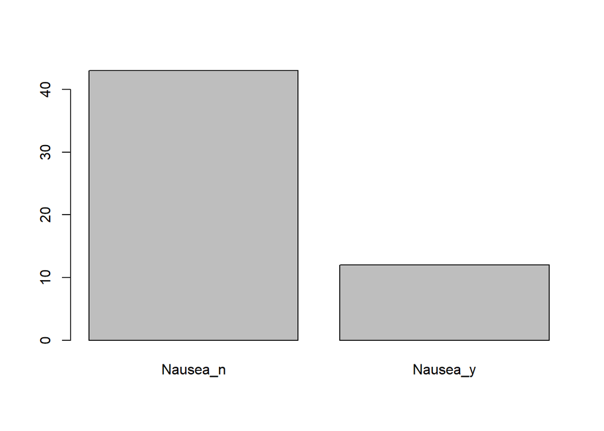

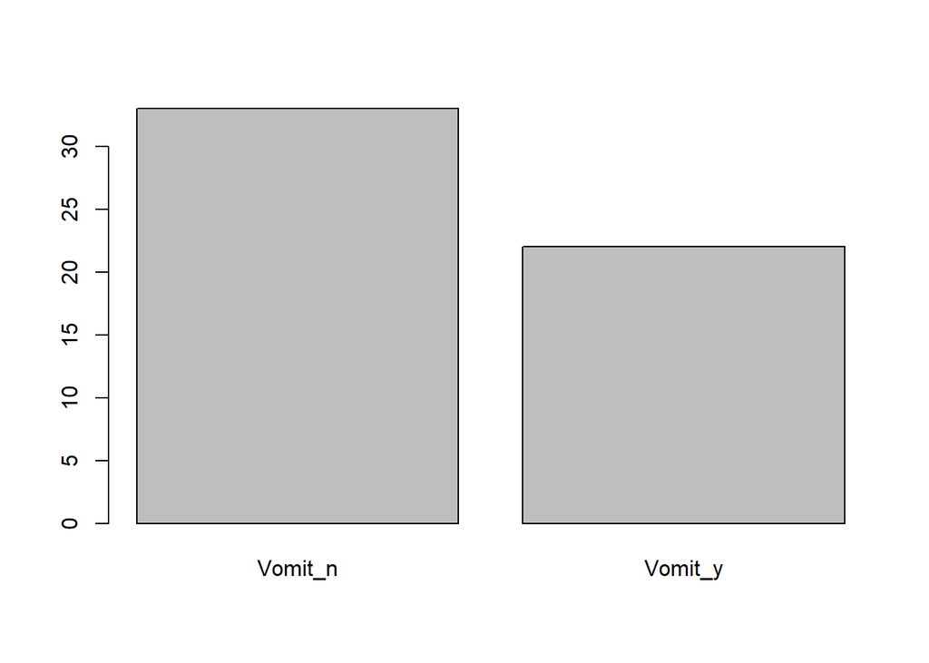

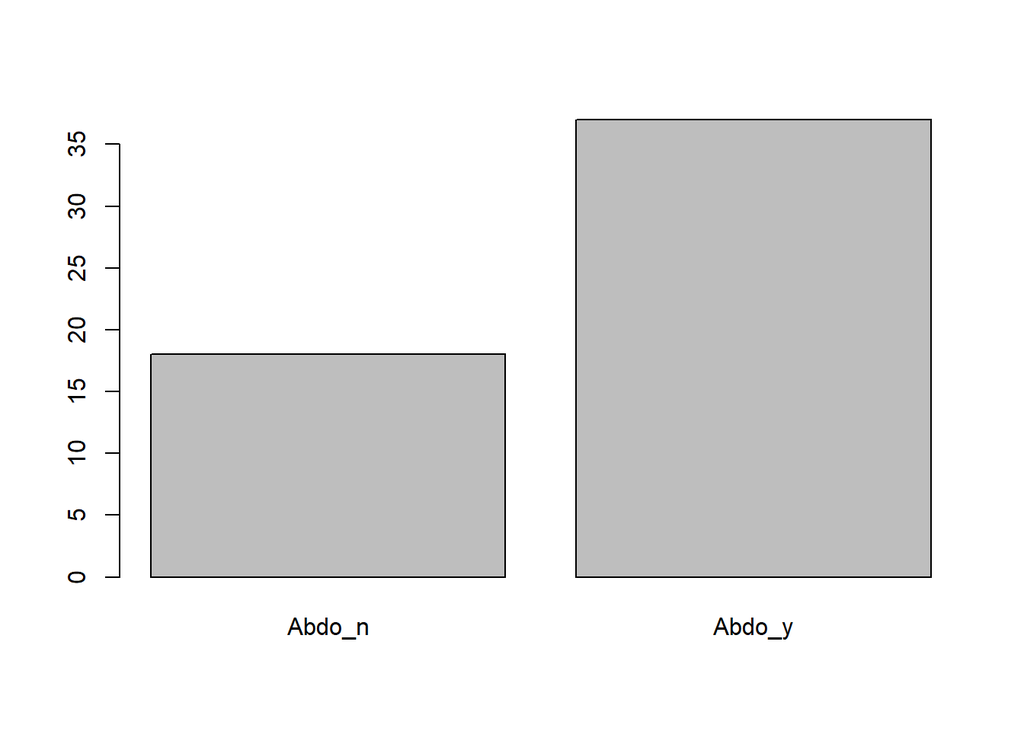

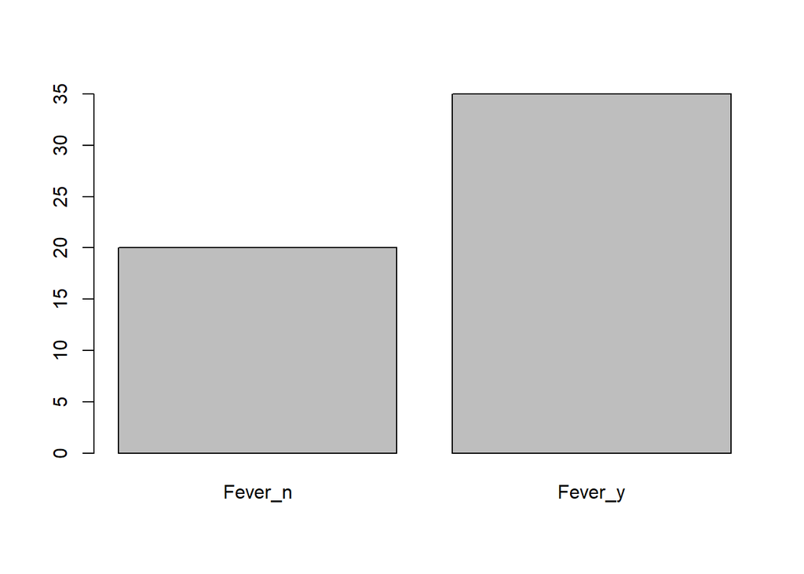

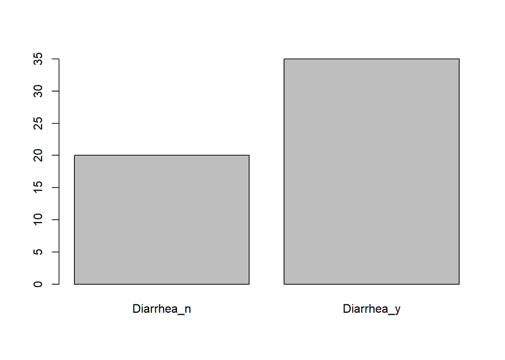

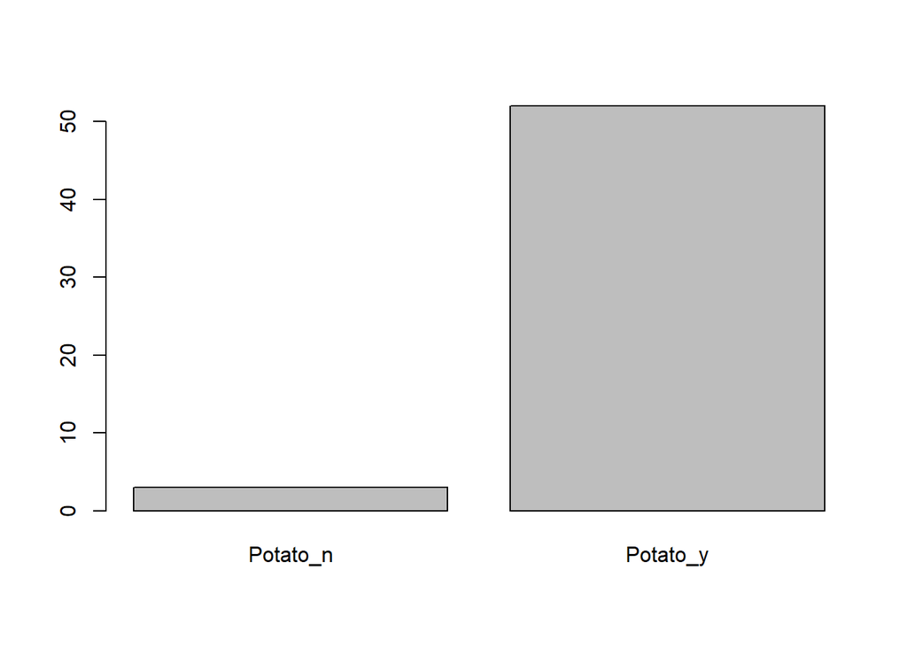

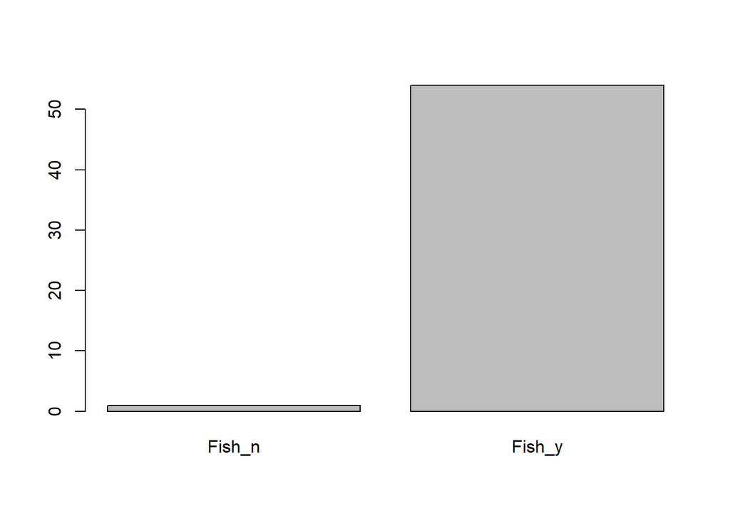

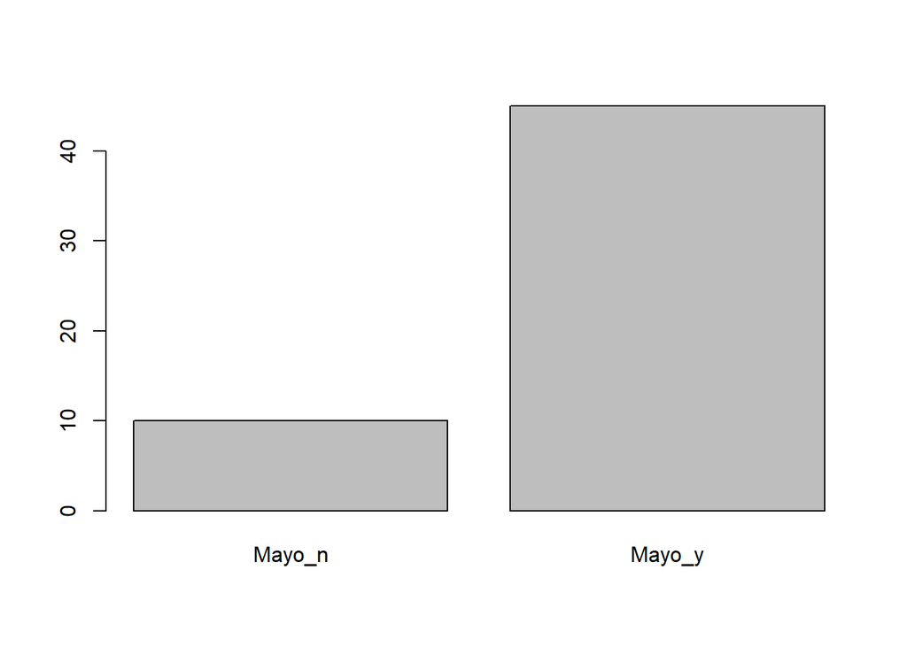

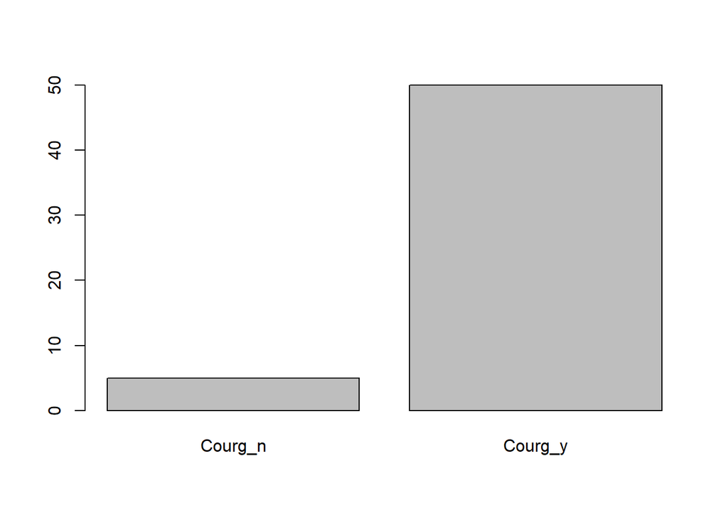

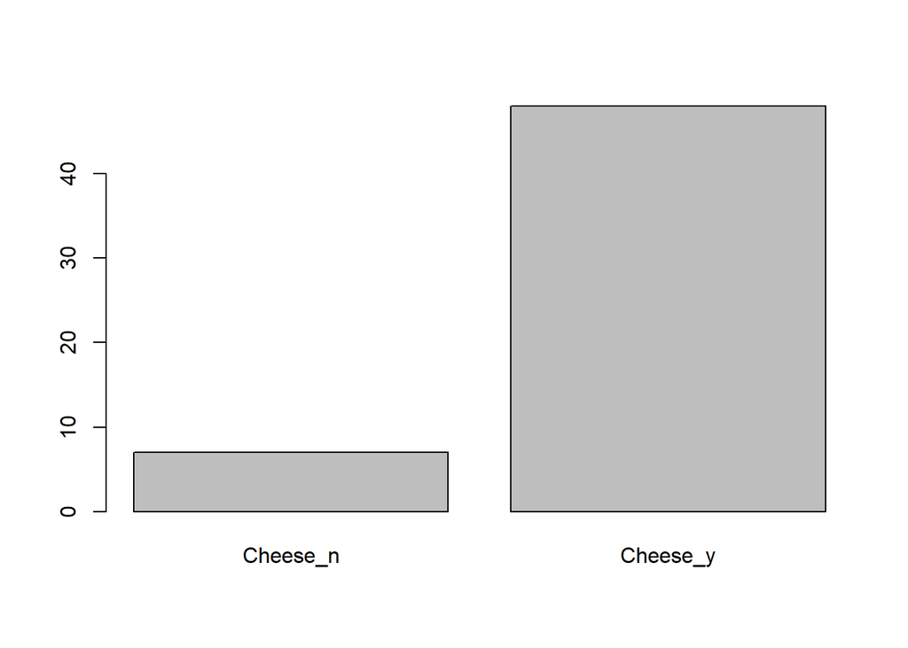

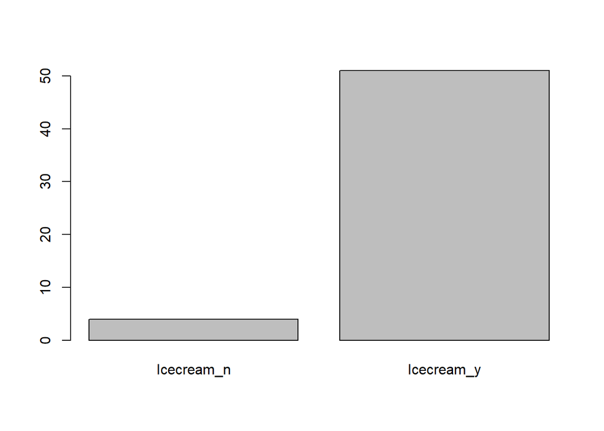

```r
poison_sympt_aliments = poison[, 5:15]
 for(i in 1:ncol(poison_sympt_aliments)){
   par(ask=TRUE)
   plot(poison_sympt_aliments[,i])}
```

Base de donnees avec les symtomes et les aliments sans les informations personnelles (age, sexe, …). C’est la base de travael ou base pour realiser l’analyse ACM.

```r
res= MCA(poison_sympt_aliments, graph = FALSE)
res
```

```
## **Results of the Multiple Correspondence Analysis (MCA)**
## The analysis was performed on 55 individuals, described by 11 variables
## *The results are available in the following objects:
##
##    name              description
## 1  "$eig"            "eigenvalues"
## 2  "$var"            "results for the variables"
## 3  "$var$coord"      "coord. of the categories"
## 4  "$var$cos2"       "cos2 for the categories"
## 5  "$var$contrib"    "contributions of the categories"
## 6  "$var$v.test"     "v-test for the categories"
## 7  "$ind"            "results for the individuals"
## 8  "$ind$coord"      "coord. for the individuals"
## 9  "$ind$cos2"       "cos2 for the individuals"
## 10 "$ind$contrib"    "contributions of the individuals"
## 11 "$call"           "intermediate results"
## 12 "$call$marge.col" "weights of columns"
## 13 "$call$marge.li"  "weights of rows"
```

ACM de la base avec chauque variables correspond a une dimension et on va construire des axes avec la participation des variables/dimensions. Chaque axe correspond a un correspondant.

```r
res$eig
```

```
##        eigenvalue percentage of variance cumulative percentage of variance
## dim 1  0.33523140              33.523140                          33.52314
## dim 2  0.12913979              12.913979                          46.43712
## dim 3  0.10734849              10.734849                          57.17197
## dim 4  0.09587950               9.587950                          66.75992
## dim 5  0.07883277               7.883277                          74.64319
## dim 6  0.07108981               7.108981                          81.75217
## dim 7  0.06016580               6.016580                          87.76876
## dim 8  0.05577301               5.577301                          93.34606
## dim 9  0.04120578               4.120578                          97.46663
## dim 10 0.01304158               1.304158                          98.77079
## dim 11 0.01229208               1.229208                         100.00000
```

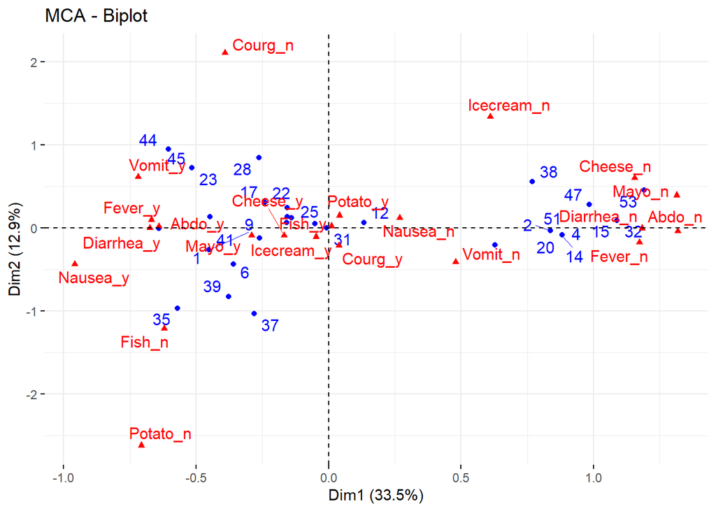

```r
fviz_mca_biplot(res, repel = TRUE, ggtheme=theme_minimal())
```

Le graphe montre la correlation entre les symptomes et la consommation d’aliments. Il faudra anslyser en terme de ‘manger aliment x’ et ‘presenter symptome y’ dans l’optique de voir les aliments qui pourraient avoir directe avec les symptomes du TIAC.

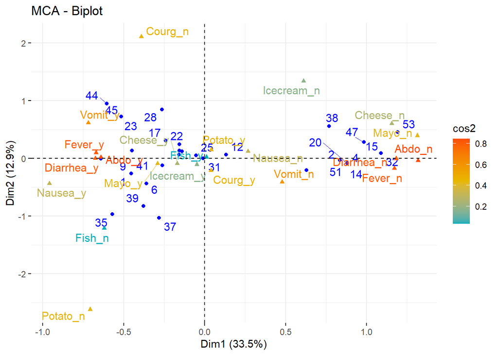

```r
fviz_mca_biplot(res, col.var='cos2', gradient.cols = c("#00AFBB", "#E7B800", "#FC4E07"),repel = TRUE, ggtheme=theme_minimal())
```

.

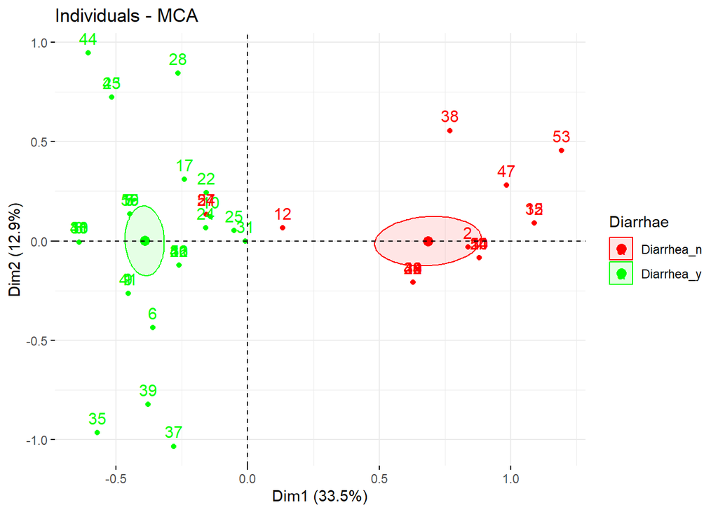

```r
fviz_mca_ind(res, label = 'all', habillage= 'Diarrhae', palette=c('red', 'green'), addEllipses=TRUE, ellipse.type='confidence', ggtheme=theme_minimal())
```

Ce graphe montre la repartion des individues solon qu’ils presentent Dirrhae ou non: C’est la reprentation en fonction d’un seul symptome (Diarrhae). NB: On peut faire la meme representation en utilisant d’autres variables.